# Project E

Mitchell Toomey

March 21, 2021

```r
library(here)
library(tidyverse)
library(hrbrthemes)
hsb2 <- read_csv(here("Data", "hsb2.csv"))
hsb2 <- as_tibble(hsb2)

hsb2
```

| id | female | race | ses | schtyp | prog | read | write | math | science | socst |
| --- | --- | --- | --- | --- | --- | --- | --- | --- | --- | --- |
| 70 | 0 | 4 | 1 | 1 | 1 | 57 | 52 | 41 | 47 | 57 |
| 121 | 1 | 4 | 2 | 1 | 3 | 68 | 59 | 53 | 63 | 61 |
| 86 | 0 | 4 | 3 | 1 | 1 | 44 | 33 | 54 | 58 | 31 |
| 141 | 0 | 4 | 3 | 1 | 3 | 63 | 44 | 47 | 53 | 56 |
| 172 | 0 | 4 | 2 | 1 | 2 | 47 | 52 | 57 | 53 | 61 |
| 113 | 0 | 4 | 2 | 1 | 2 | 44 | 52 | 51 | 63 | 61 |
| 50 | 0 | 3 | 2 | 1 | 1 | 50 | 59 | 42 | 53 | 61 |
| 11 | 0 | 1 | 2 | 1 | 2 | 34 | 46 | 45 | 39 | 36 |
| 84 | 0 | 4 | 2 | 1 | 1 | 63 | 57 | 54 | 58 | 51 |
| 48 | 0 | 3 | 2 | 1 | 2 | 57 | 55 | 52 | 50 | 51 |

[output cut: 190 more lines]

### 1

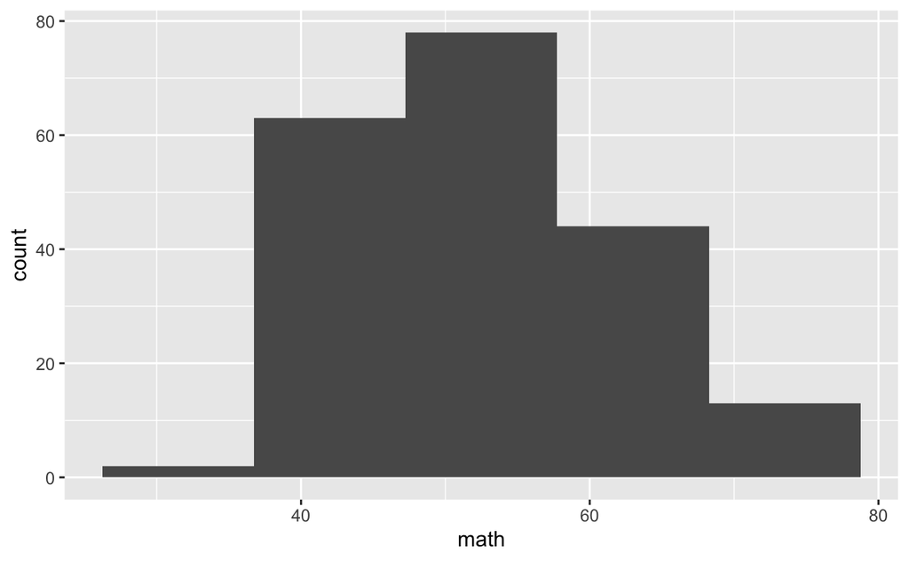

```r
ggplot(hsb2, aes(x=math)) +
  geom_histogram(bins = 5)
```

### 2

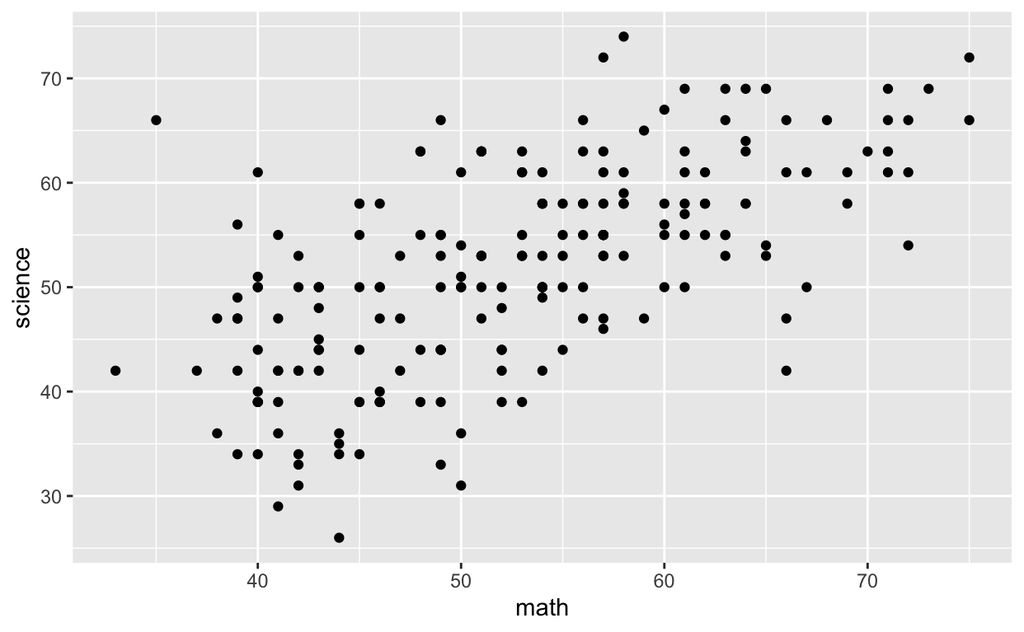

```r
ggplot(hsb2, aes(x=math, y=science)) +
    geom_point()
```

### 3

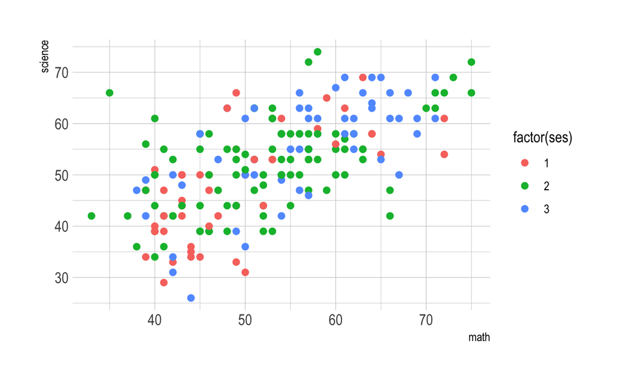

```r
library(hrbrthemes)

ggplot(hsb2, aes(x=math, y=science, color=factor(ses))) +
    geom_point(size=2) +
    theme_ipsum()
```

### 4

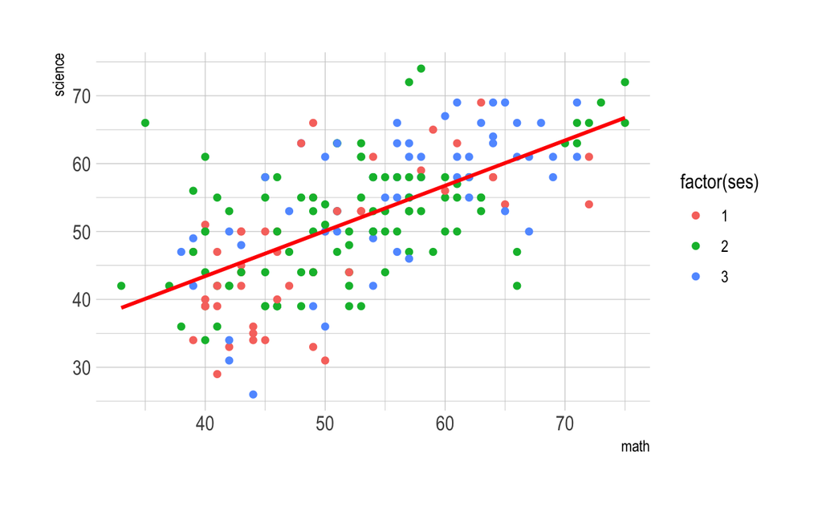

```r
sp <- ggplot(hsb2, aes(x=math, y=science, color=factor(ses))) +
  geom_point() +
  geom_smooth(method=lm , color="red", se=FALSE) +
  theme_ipsum()

sp
```

### 5

The first layer included the dataset in a data frame, and the aesthetics The second layer was a geometric object indicating the size of the plots The third layer was a theme which made the scatterplot a specific color and font

### 6 making two faceted scatterplots around the relationship between math scores and science scores by school type (public vs. private)

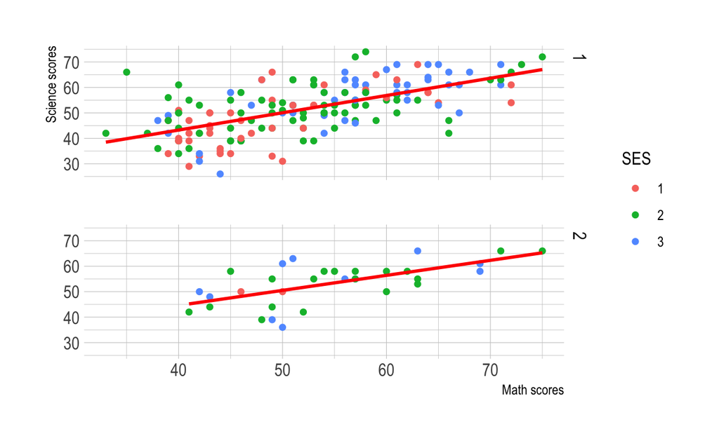

```r
sp + facet_grid(schtyp ~ .) +
  labs(x="Math scores", y="Science scores", color="SES")
```

```r
# 1 is public
# 2 is private
```

### 7 math scores compared across ses, with 1 = low, 2 = middle, 3 = high

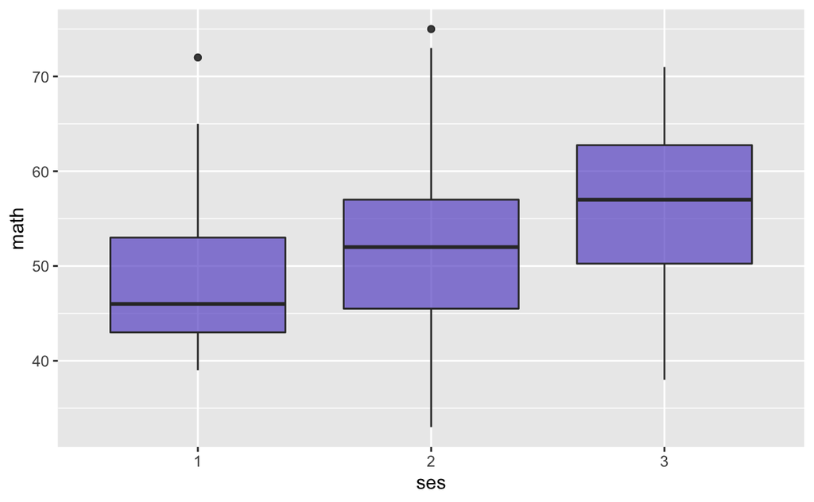

```r
ggplot(hsb2, aes(x=as.factor(ses), y=math)) +
    geom_boxplot(fill="slateblue", alpha=0.7) +
    xlab("ses")
```

### 8 - side-by-side boxplots of math scores by ses, with individual observations accounted for

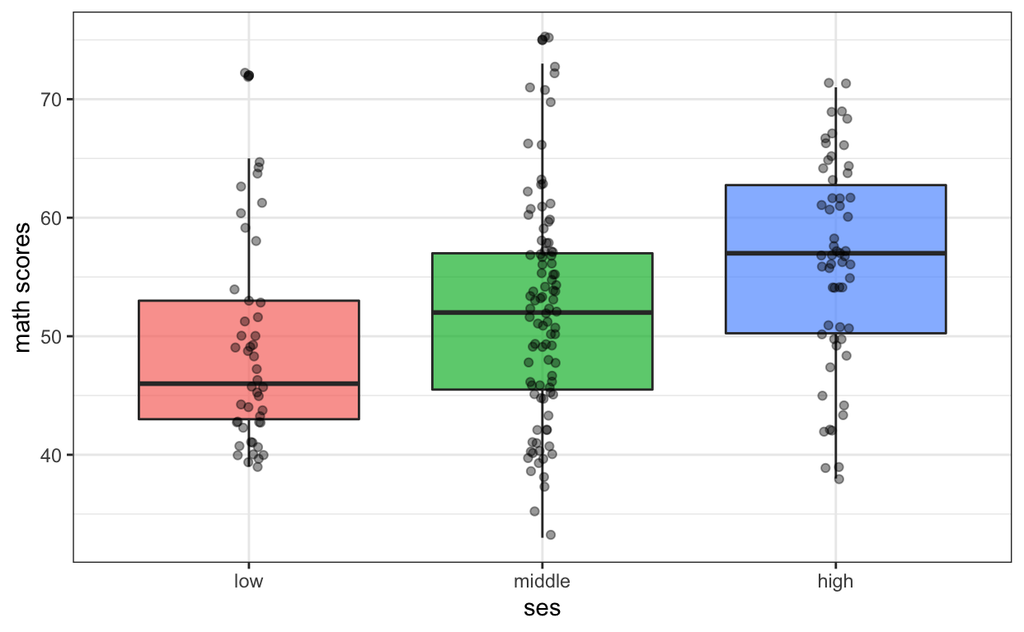

```r
hsb2 %>%
  mutate(ses = factor(ses, levels = c(1, 2, 3), labels = c("low", "middle", "high"))) %>%
  ggplot(aes(x = ses, y = math, group = ses, fill = ses)) +
    geom_boxplot(alpha = .7) +
    geom_jitter(width = .05, alpha = .4) +
    guides(fill = "none") +
    theme_bw() +
    labs(
      x = "ses",
      y = "math scores"
    )
```

### 9 - side-by-side boxplots of math scores by ses, with individual observations accounted for, and mean math scores indicated by the red dots

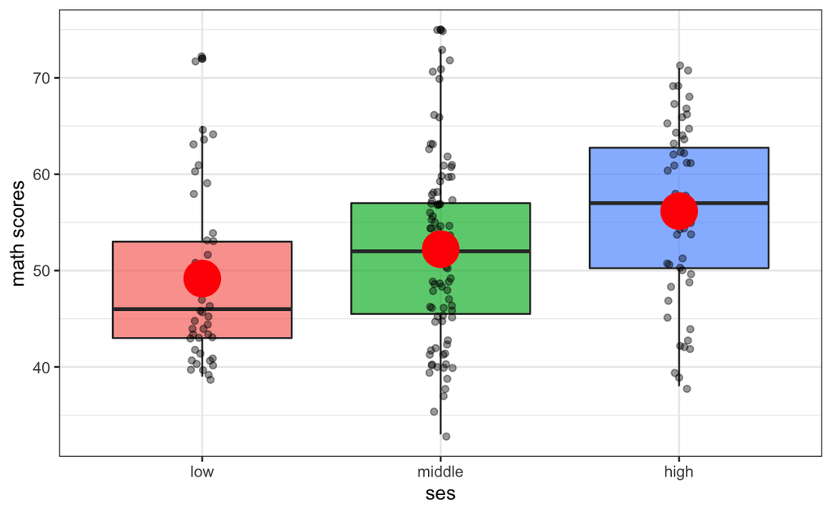

```r
hsb2 %>%
  mutate(ses = factor(ses, levels = c(1, 2, 3), labels = c("low", "middle", "high"))) %>%
  ggplot(aes(x = ses, y = math, group = ses, fill = ses)) +
    geom_boxplot(alpha = .7) +
    geom_jitter(width = .05, alpha = .4) +
    guides(fill = "none") +
    stat_summary(fun=mean, geom="point", shape=20, size=14, color="red",
                 fill="red") +
    theme_bw() +
    labs(
      x = "ses",
      y = "math scores"
    )
```

### 10

```
Ignoring unknown parameters: stat
```

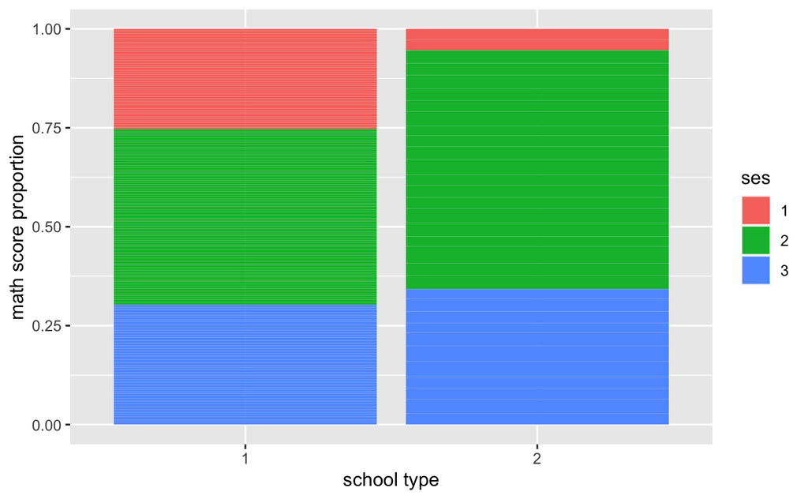

```r
# Grouped by ses
ggplot(hsb2, aes(x=factor(schtyp), y=math, fill=factor(ses))) +
    geom_col(position = "fill", stat = "identity") +
    labs(x="school type", y="math score proportion", fill="ses")
```

### 11

Use the mental health study data to graphically explore the relationship of life events and SES on mental health impairment. Your graph should illustrate whether SES moderates the influence of life events on mental health.

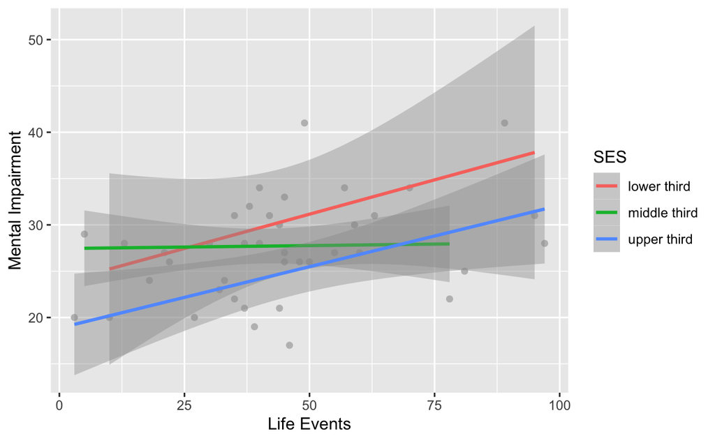

```r
# read in mh data
mh_data <- read_csv(here("Data", "Mental Health Study Data.csv"))
# break SES into three groups
mh_data$SES_groups <- cut(mh_data$SES, breaks = 3) %>%
  factor(., labels = c("lower third", "middle third", "upper third"))

# plot the moderating relationship of ses
ggplot(mh_data) +
  aes(x = LifeEvts, y = MentImp, color = mh_data$SES_groups) +
  geom_point(color = "grey") +
  geom_smooth(method = "lm") +
  labs(x="Life Events", y="Mental Impairment", color="SES")
```

```r
NA
NA
```

There is a positive relationship bt life events and mental impairment, and this is stronger for individuals from lower SES.

### 12

Use the notes study data to graphically explore the relationship of method of note taking to later recall. Your graph should illustrate whether the type of lecture moderates the effect of note taking method on recall.

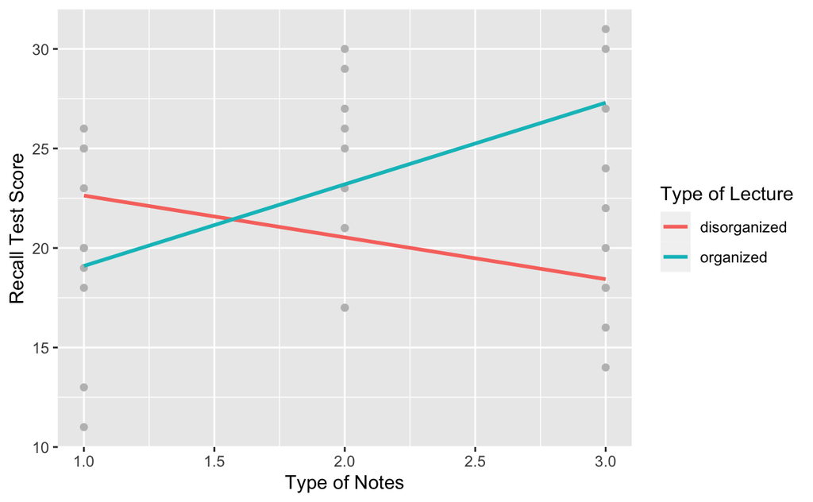

```r
# read in notes data
notes_data <- read_csv(here("Data", "Notes Data.csv"))
notes_data$lecture_type <- factor(notes_data$lecture,
                                  levels = c(1, 2),
                                  labels = c("disorganized", "organized"))

# plot the moderating relationship of ses
ggplot(notes_data) +
  aes(x = notes, y = score, color = lecture_type) +
  geom_point(color = "grey") +
  geom_smooth(method = "lm", se = FALSE) +
  labs(x="Type of Notes", y="Recall Test Score", color="Type of Lecture")
```

Type of lecture moderates the relationship between type of notes and recall test scores, such that there is a positive relationship between type of note and recall test scores in organized lectures, and a negative relationship for disorganized lectures.

### 13

For this exercise, use a data set of interest to you (preferably one from your own research study or perhaps a study you have worked on with a professor, though this is not a requirement) that includes at least five variables with at least one of each type (categorical and quantitative). Visually display relationships of multiple variables with a single graph (Faceting is allowed). Your points for this exercise will be based on the attractiveness of your graph, the number of variables you were able to informatively include, and the amount of information that can be extracted from your graph. (Think Hans Rosling!)

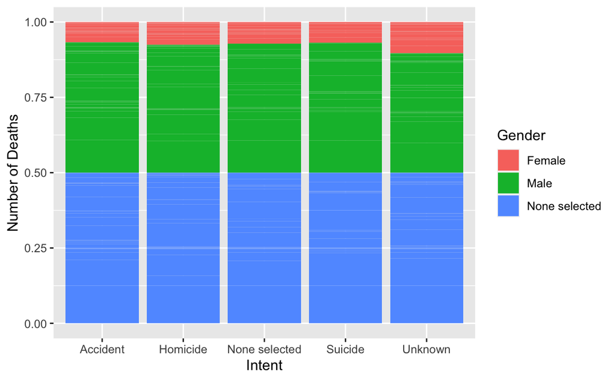

```r
# using the guns data from earlier in the course
guns_data <- read_csv(here("Data", "guns.csv"))
# This created a stacked bar with proportions of gun deaths based on gender
ggplot(guns_data, aes(x=factor(Intent), y=Deaths, fill=factor(Gender))) +
    geom_col(position = "fill") +
    labs(x="Intent", y="Number of Deaths", fill="Gender")
```

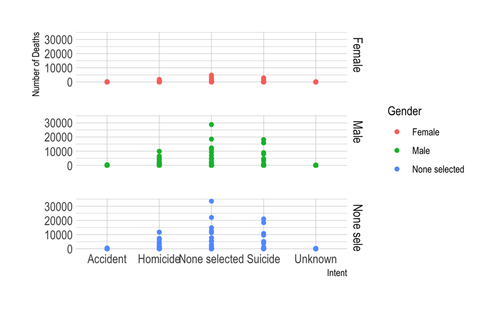

```r
# Below is something I was playing with. Will delete probably after the tutorial
# session
# make a scatterplot faceted by gender for the relationship between gun deaths and
# intent

gd <- ggplot(guns_data, aes(x=Intent, y=Deaths, color=factor(Gender))) +
  geom_point() +
  geom_smooth(method=lm , color="red", se=FALSE) +
  theme_ipsum()

# facet the scatter plots to show multiple relationships
gd + facet_grid(Gender ~ .) +
  labs(x="Intent", y="Number of Deaths", color="Gender")
```